# GUIA 3

### Miembros

- Valeria Alvarez
- Jonathan Alonso

#### Repositorio

Se puede encontrar el repositorio de Github de esta actividad en el siguiente link:

- https://github.com/valalzarate/Guia-3

##### Actividad 1. Filtros y cruces

Producto realice lo siguiente:

- Transformación del tipo de dato.
- Cruce de tablas.
- Filtro de variables por algún tipo de criterio.
- Enviar el archivo en formato HTML al tutor en la plataforma.

Recomendaciones:

- Orientar el acercamiento a los materiales de estudio.
- Asegura coherencia y suficiente detalle en la secuencia instruccional.
- Detalle las características del entregable.
- Incluir en las instrucciones cómo y cuándo utilizar los recursos de aprendizaje.
  - Se recomienda trabajar en parejas para la revisión de las variables en la base de datos dada.
  - Cargar la base de datos dada y empezar a revisar las variables.
  - Determinar el tipo de cada una de las variables.
  - Aplicar las funciones revisadas, según cada tipo de variable.
  - Realizar la limpieza de la variable NIT proveedor.
  - Transformar la variable del Nit.
  - Cruzar las bases de SECOP I con la del SECOP II.
  - Realizar un informe sobre las variables que se exploraron.

#### Exploracion de datos

```python
#Se importan las librerias de interes
import pandas as pd
import numpy as np
import matplotlib.pyplot as plt
#Se leen las bases de datos dadas
df = pd.read_csv('datos_secop_I_modified.csv',delimiter=',')
print(df.shape)
df.head()
```

```
(1000, 19)
```

|  | identificador_paa | codigo_entidad | nombre_entidad | nit_entidad | anno_paa | direccion_entidad | telefono_entidad | mision_y_vision | perspectiva_estrategica | info_contacto | ppto_total | limite_menor_cuantia | limite_minima_cuantia | fecha_ultima_actualizacion | fecha_cargue | municipio_paa | departamento_paa | localidad_paa | codigo_municipio |
| --- | --- | --- | --- | --- | --- | --- | --- | --- | --- | --- | --- | --- | --- | --- | --- | --- | --- | --- | --- |
| 0 | 303062 | 28500134 | CASANARE ESE HOSPITAL DE YOPAL ! | 891855029 | 2022 | Calle 15 N 795 Manzana L via marginal de la selva | 6344699 | MisionEl Hospital Regional de la Orinoquia es ... | el Hospital Regional de la Orinoqua ESE se con... | Almacen Hospital Regional de la Orinoquia Cont... | 126898133557 | NaN | $nan | 12/31/21 | 2022-01-31T11:53:47.000 | Yopal | Casanare | PLAN UNICO | 85001 |
| 1 | 294652 | 205001279 | ANTIOQUIA INSTITUCIN EDUCATIVA DBORA ARANGO P... | 900196642 | 2022 | Calle 118 103160 | 5294058 | MISION La Institucin Educativa Dbora Arango de... | Direccionar la Institucin para el logro del ho... | Carlos Enrique Rojas Sanchez | $84026639 | 0 | 20000000 | 12/1/21 | 2022-01-26T09:43:07.000 | Medellín | Antioquia | UNICO PLAN | 5001 |
| 2 | 259436 | 286571031 | PUTUMAYO CENTRO EDUCATIVO RURAL SAUDITA PUER... | 846004233-5 | 2021 | VEREDA SAUDITA | 3208339785 | MISION El Centro Educativo Rural Saudita garan... | 0 | 3208339785 | $107700000 | 254387280 | $25438728 | 11/27/20 | 2021-01-28T02:34:58.000 | Puerto Guzmán | Putumayo | UNICO PLAN | 86571 |
| 3 | 263541 | 205001191 | ANTIOQUIA INSTITUCIN EDUCATIVA SAN CRISTBAL ... | 811017472 | 2021 | Carrera 131 No 65 07 | 4279180 | 2021 | wwwiesancristobaleduco | La Institucin Educativa San Cristbal ofrece ... | La Institucin educativa San Cristbal Lder en l... | JOSE CHARLES VELEZ BETANCURRectoriesancristoba... | 159239220 | 181705200 | 2021-01-29T04:15:31.000 | Medellín | Antioquia | UNICO PLAN | 5001 |
| 4 | 298985 | 250226019 | META CENTRO EDUCATIVO RURAL JOSE MARIA GUIOTH... | 900134298-9 | 2022 | Vda Caney Medio Km2CumaralMeta | 3013604535 | Misin | Mejoramiento de la calidad educativa en la pre... | LUIS FERNANDO ROJAS SALAZAR CC 17267322 Cargo ... | $22500000 | 280000000 | $28000000 | 12/2/21 | 2022-01-28T07:06:52.000 | Cumaral | Meta | UNICO PLAN | 50226 |

```python
#Vemos las columnas
df.columns
```

```
Index(['identificador_paa', 'codigo_entidad', 'nombre_entidad', 'nit_entidad',
       'anno_paa', 'direccion_entidad', 'telefono_entidad', 'mision_y_vision',
       'perspectiva_estrategica', 'info_contacto', 'ppto_total',
       'limite_menor_cuantia', 'limite_minima_cuantia',
       'fecha_ultima_actualizacion', 'fecha_cargue', 'municipio_paa',
       'departamento_paa', 'localidad_paa', 'codigo_municipio'],
      dtype='object')
```

```python
#Observamos tipo de datos
df.dtypes
```

```
identificador_paa              int64
codigo_entidad                 int64
nombre_entidad                object
nit_entidad                   object
anno_paa                       int64
direccion_entidad             object
telefono_entidad              object
mision_y_vision               object
perspectiva_estrategica       object
info_contacto                 object
ppto_total                    object
limite_menor_cuantia          object
limite_minima_cuantia         object
fecha_ultima_actualizacion    object
fecha_cargue                  object
municipio_paa                 object
departamento_paa              object
localidad_paa                 object
codigo_municipio               int64
dtype: object
```

```python
#Resumen variables numericas
df.describe()
```

|  | identificador_paa | codigo_entidad | anno_paa | codigo_municipio |
| --- | --- | --- | --- | --- |
| count | 1000.000000 | 1.000000e+03 | 1000.000000 | 1000.000000 |
| mean | 295795.588000 | 1.781937e+08 | 2021.682000 | 40750.462000 |
| std | 25046.125875 | 1.007772e+08 | 0.739881 | 27234.821954 |
| min | 219842.000000 | 2.538170e+05 | 2020.000000 | 1101.000000 |
| 25% | 274957.750000 | 2.888282e+07 | 2021.000000 | 15777.000000 |
| 50% | 297910.500000 | 2.176590e+08 | 2022.000000 | 41396.000000 |
| 75% | 318159.000000 | 2.524203e+08 | 2022.000000 | 68307.000000 |
| max | 338576.000000 | 2.990010e+08 | 2023.000000 | 99773.000000 |

```python
#Resumen Variables objeto
df.describe(include='object')
```

|  | nombre_entidad | nit_entidad | direccion_entidad | telefono_entidad | mision_y_vision | perspectiva_estrategica | info_contacto | ppto_total | limite_menor_cuantia | limite_minima_cuantia | fecha_ultima_actualizacion | fecha_cargue | municipio_paa | departamento_paa | localidad_paa |
| --- | --- | --- | --- | --- | --- | --- | --- | --- | --- | --- | --- | --- | --- | --- | --- |
| count | 1000 | 1000 | 1000 | 1000 | 997 | 950 | 998 | 998 | 990 | 990 | 989 | 1000 | 1000 | 1000 | 1000 |
| unique | 970 | 946 | 950 | 920 | 940 | 804 | 919 | 935 | 302 | 260 | 508 | 974 | 511 | 32 | 272 |
| top | CAQUET ALCALDA MUNICIPIO DE EL DONCELLO | No Definido | No Definido | No Definido | No Definido | No Definido | No Definido | $0 | $280000000 | 25438728 | 1/31/22 | 2022-01-31T11:53:47.000 | Bogotá D.C. | Cundinamarca | UNICO PLAN |
| freq | 3 | 22 | 19 | 28 | 22 | 45 | 28 | 23 | 96 | 102 | 41 | 2 | 44 | 93 | 596 |

#### Correjimos los tipos de datos

los tipos de datos a cambiar son:

- identificador_paa: str
- codigo_entidad: str
- codigo_municipio: str
- ppto_total: float
- limite_menor_cuantia: float
- limite_minima_cuantia: float
- fecha_ultima_actualizacion: datetime
- fecha_cargue: timestamp

```python
df['identificador_paa']=df['identificador_paa'].astype(str)
df['codigo_entidad']=df['codigo_entidad'].astype(str)
df['identificador_paa']=df['identificador_paa'].astype(str)
df['codigo_municipio']=df['codigo_municipio'].astype(str)
df['ppto_total']= df['ppto_total'].apply(lambda x: x.replace('$','') and x.replace('.','') if isinstance(x, str) else x )
df['limite_menor_cuantia']= df['limite_menor_cuantia'].apply(lambda x: x.replace('$','') and x.replace('.','')  if isinstance(x, str) else x)
df['limite_minima_cuantia']= df['limite_minima_cuantia'].apply(lambda x: x.replace('$','') and x.replace('.','') if isinstance(x, str) else x)
```

```python
#convertir variables en float, de no poderse se retorna None
def safe_convert_to_float(value):
    try:
        return float(value)
    except (ValueError, TypeError):
        return None
```

```python
df['ppto_total'] = df['ppto_total'].apply(safe_convert_to_float)
df['limite_menor_cuantia']= df['limite_menor_cuantia'].apply(safe_convert_to_float)
df['limite_minima_cuantia']= df['limite_minima_cuantia'].apply(safe_convert_to_float)
```

```python
#Se convierte el valor de fecha a datetime, de no poderse se retorna None
def safe_convert_to_date(value):
    try:
        return pd.to_datetime(value,format='%m/%d/%y')
    except:
        try:
            return pd.to_datetime(value,format='%d%m%y')
        except:
            try:
                return pd.to_datetime(value,format='%d de %B de %Y')
            except (ValueError, TypeError):
                return None
```

```python
df['fecha_ultima_actualizacion']=df['fecha_ultima_actualizacion'].apply(safe_convert_to_date)
```

```python
#Se convierten valores a Timestamp, de no poderse retorna None
def safe_convert_to_timestamp(value):
    try:
        return pd.Timestamp(value)
    except (ValueError, TypeError):
        return None  # O un valor predeterminado de tu elección
```

```python
df['fecha_cargue']=df['fecha_cargue'].apply(safe_convert_to_timestamp)
```

```python
df['nit_entidad']=df['nit_entidad'].apply(lambda x: x.replace('.',''))
df['nit_entidad']=df['nit_entidad'].apply(lambda x: x[:9])
df['nit_entidad']=df['nit_entidad'].apply(safe_convert_to_float)
df['nit_entidad']=df['nit_entidad'].astype(str)
```

```python
df.describe()
```

|  | anno_paa | ppto_total | limite_menor_cuantia | limite_minima_cuantia | fecha_ultima_actualizacion | fecha_cargue |
| --- | --- | --- | --- | --- | --- | --- |
| count | 1000.000000 | 4.430000e+02 | 4.160000e+02 | 4.270000e+02 | 651 | 1000 |
| mean | 2021.682000 | 4.072004e+11 | 7.351091e+09 | 6.375313e+08 | 2021-09-03 08:02:12.718894080 | 2021-12-25 13:29:01.853999872 |
| min | 2020.000000 | 0.000000e+00 | 0.000000e+00 | 0.000000e+00 | 2000-01-20 00:00:00 | 2020-01-28 09:00:15 |
| 25% | 2021.000000 | 5.371135e+07 | 2.457848e+08 | 2.543873e+07 | 2021-01-29 00:00:00 | 2021-02-10 07:18:16 |
| 50% | 2022.000000 | 1.687010e+08 | 2.543873e+08 | 2.800000e+07 | 2021-12-03 00:00:00 | 2022-01-28 03:04:21 |
| 75% | 2022.000000 | 3.256144e+09 | 2.800041e+08 | 3.248000e+07 | 2022-01-31 00:00:00 | 2022-06-23 01:45:54.500000 |
| max | 2023.000000 | 5.596688e+13 | 1.926470e+12 | 8.694032e+10 | 2023-12-31 00:00:00 | 2023-10-31 03:32:25 |
| std | 0.739881 | 3.368711e+12 | 9.643496e+10 | 5.258635e+09 | NaN | NaN |

#### Informe SECOP I

Se realizó una limpieza preliminar de los datos en la que se identificaron y corrigieron valores erróneos en varias columnas, utilizando funciones de manejo de errores (try-except) para reemplazar los valores incorrectos por NaN y evitar la corrupción de los datos.

El análisis de la tabla muestra que los datos cubren el período de 2020 a 2023, con una amplia variabilidad en los valores de presupuesto total y límites. Las medias son significativamente mayores que las medianas, lo que indica la presencia de valores extremos altos. La alta dispersión y las elevadas desviaciones estándar sugieren que algunos registros son notablemente altos en comparación con la mayoría. Las fechas de actualización y carga van desde el año 2000 hasta 2023, reflejando un proceso continuo de registro y actualización. Se recomienda realizar un análisis más detallado de los valores atípicos y la distribución para obtener una comprensión más precisa de los datos.

#### Exploramos datos de df2

```python
df2 = pd.read_csv('datos_secov_II_modified.csv',delimiter=';',encoding='latin-1')
df.shape
```

```
(1000, 19)
```

```python
df2.head()
```

|  | identificador_unico | id_plan_anual_de_adquisiciones | anno | nit_entidad | nombre_entidad | mision_vision | perspectiva_estrategica | nombre_contacto | telefono_contacto | correo_contacto | ... | presupuesto_menor_cuantia | presupuesto_minima_cuantia | fecha_de_publicacion | fecha_de_creacion | fecha_de_ultima_modificacion | version | identificador_requerimiento_compra | estado | departamento_paa | municipio_paa |
| --- | --- | --- | --- | --- | --- | --- | --- | --- | --- | --- | --- | --- | --- | --- | --- | --- | --- | --- | --- | --- | --- |
| 0 | CO1.APP.2041264 | MarketplaceCO1538159 | 2024 | 721520377 | INSTITUCION EDUCATIVA AGROPECUARIA MAXIMO GOMEZ | MISION 2023 2026 La Institucin Educativa Agrop... | Ser una institucin destacada por sus estrategi... | MARIA EUGENIA LEDESMA LLANTEN | 3104661182 | mariaeugenia.maestra@gmail.com | ... | $26000000.0 | $2600000.0 | 2024-07-31 03:47:42.6041815 | 2024-08-23 07:11:00.0000000 | 2024-08-22 20:32:26.391947400 | 2 | CO1.PPI.33807381 | Borrador | Cauca | Cajibío |
| 1 | CO1.APP.2041602 | MarketplaceCO1538240 | 2024 | 718938582 | INSTITUCION EDUCATIVA MUNICIPAL EL SOCORRO | MISION Brindar una formacin acadmica que forme... | El proceso de formacin de los educandos debe e... | RAFAEL BASTIDAS SANCHEZ | 3136820189 | rafabastidas@hotmail.com | ... | $845000000.0 | $84500000.0 | 2024-01-31 16:19:08.5384812 | 2024-08-23 07:11:00.0000000 | 2024-08-22 22:00:52.607658300 | 13 | CO1.PPI.33809817 | No especificado | Nariño | Pasto |
| 2 | CO1.APP.2041198 | MarketplaceCO1538184 | 2024 | 703036004 | MUNICIPIO LA DORADA | La administracin municipal regir los destinos ... | La Dorada ser un municipio competitivo y soste... | JULIAN DAVID OLIVEROS SERRANO | 8572013 | compras@ladorada-caldas.gov.co | ... | $364000000.0 | $36400000.0 | 2024-01-17 20:54:03.3001599 | 2024-08-23 07:11:00.0000000 | 2024-08-22 21:03:45.672865800 | 28 | CO1.PPI.33808340 | Borrador | Caldas | La Dorada |
| 3 | CO1.APP.2041074 | MarketplaceCO1538121 | 2024 | 723119863 | COOAGUAS DE PUEBLO NUEVO E.S.P. | MISION LA ADMINISTRACION PBLICA COOPERATIVA EM... | POLITICA DE CALIDAD Somos un organismo pblico ... | CARLOS FERNANDO GERMAN CALAO | 3127695263 | carlosgcalao@outlook.com | ... | 174000000.0 | 116000000.0 | 2024-02-01 02:01:48.3772533 | 2024-08-23 07:11:00.0000000 | 2024-08-22 19:47:30.908245300 | 2 | CO1.PPI.33805980 | Borrador | Córdoba | Pueblo Nuevo |
| 4 | CO1.APP.2041030 | MarketplaceCO1415172 | 2024 | 705153815 | MUNICIPIO DE LA PLATA | Gestionar servir a la comunidad promover el bi... | A travs de la implementacin del presente Plan ... | CRISTINA HOLGUIN GRISALES | 3223001245 | almacen@laplata-huila.gov.co | ... | $364000000.0 | $36400000.0 | 2024-01-10 15:55:50.6223556 | 2024-08-23 07:11:00.0000000 | 2024-08-22 15:48:03.701324800 | 148 | CO1.PPI.33799556 | Publicado | Huila | La Plata |

5 rows × 21 columns

```python
df2.describe()
```

|  | anno | version |
| --- | --- | --- |
| count | 1000.000000 | 1000.000000 |
| mean | 2022.984000 | 33.862000 |
| std | 1.685997 | 66.973774 |
| min | 2016.000000 | 1.000000 |
| 25% | 2023.000000 | 3.000000 |
| 50% | 2024.000000 | 9.000000 |
| 75% | 2024.000000 | 37.250000 |
| max | 2025.000000 | 818.000000 |

```python
df.describe(include='object')
```

|  | identificador_paa | codigo_entidad | nombre_entidad | nit_entidad | direccion_entidad | telefono_entidad | mision_y_vision | perspectiva_estrategica | info_contacto | municipio_paa | departamento_paa | localidad_paa | codigo_municipio |
| --- | --- | --- | --- | --- | --- | --- | --- | --- | --- | --- | --- | --- | --- |
| count | 1000 | 1000 | 1000 | 1000 | 1000 | 1000 | 997 | 950 | 998 | 1000 | 1000 | 1000 | 1000 |
| unique | 974 | 941 | 970 | 882 | 950 | 920 | 940 | 804 | 919 | 511 | 32 | 272 | 524 |
| top | 303062 | 218247011 | CAQUET ALCALDA MUNICIPIO DE EL DONCELLO | nan | No Definido | No Definido | No Definido | No Definido | No Definido | Bogotá D.C. | Cundinamarca | UNICO PLAN | 1101 |
| freq | 2 | 3 | 3 | 50 | 19 | 28 | 22 | 45 | 28 | 44 | 93 | 596 | 44 |

```python
df2.dtypes
```

```
identificador_unico                   object
id_plan_anual_de_adquisiciones        object
anno                                   int64
nit_entidad                           object
nombre_entidad                        object
mision_vision                         object
perspectiva_estrategica               object
nombre_contacto                       object
telefono_contacto                     object
correo_contacto                       object
valor_presupuesto_general             object
presupuesto_menor_cuantia             object
presupuesto_minima_cuantia            object
fecha_de_publicacion                  object
fecha_de_creacion                     object
fecha_de_ultima_modificacion          object
version                                int64
identificador_requerimiento_compra    object
estado                                object
departamento_paa                      object
municipio_paa                         object
dtype: object
```

#### Correjimos los tipos de datos

los tipos de datos a cambiar son:

- valor_presupuesto_general: float
- presupuesto_menor_cuantia: float
- presupuesto_minima_cuantia: float
- fecha_de_publicacion: timestamp

```python
df2['valor_presupuesto_general']=df2['valor_presupuesto_general'].apply(lambda x: x.replace('$','') and x.replace('.','') if isinstance(x, str) else x ).apply(safe_convert_to_float)
df2['presupuesto_menor_cuantia']=df2['presupuesto_menor_cuantia'].apply(lambda x: x.replace('$','') and x.replace('.','') if isinstance(x, str) else x ).apply(safe_convert_to_float)
df2['presupuesto_minima_cuantia']=df2['presupuesto_minima_cuantia'].apply(lambda x: x.replace('$','') and x.replace('.','') if isinstance(x, str) else x ).apply(safe_convert_to_float)
```

```python
df2['fecha_de_publicacion']=df2['fecha_de_publicacion'].apply(safe_convert_to_timestamp)
df2['fecha_de_creacion']=df2['fecha_de_creacion'].apply(safe_convert_to_timestamp)
df2['fecha_de_ultima_modificacion']=df2['fecha_de_ultima_modificacion'].apply(safe_convert_to_timestamp)
df2['nit_entidad']=df2['nit_entidad'].apply(lambda x: x[:9])
```

#### Informe SECOP II

Se limpiaron los datos monetarios para permitir un análisis más preciso y se convirtieron las fechas a formato timestamp.

```python
df.merge(df2, on='nit_entidad')
```

|  | identificador_paa | codigo_entidad | nombre_entidad_x | nit_entidad | anno_paa | direccion_entidad | telefono_entidad | mision_y_vision | perspectiva_estrategica_x | info_contacto | ... | presupuesto_menor_cuantia | presupuesto_minima_cuantia | fecha_de_publicacion | fecha_de_creacion | fecha_de_ultima_modificacion | version | identificador_requerimiento_compra | estado | departamento_paa_y | municipio_paa_y |
| --- | --- | --- | --- | --- | --- | --- | --- | --- | --- | --- | --- | --- | --- | --- | --- | --- | --- | --- | --- | --- | --- |

0 rows × 39 columns

#### Conclusión Actividad I

la base de datos SECOP I y SECOP II no comparten registros en común, por lo cual procedermos a realizar concatenación de datos y realizar la revisión de la información pertinente

```python
#Seleccionamos las columnas de interes
secop2=df2[['anno', 'departamento_paa','fecha_de_creacion','fecha_de_publicacion','fecha_de_ultima_modificacion',
 'municipio_paa','nit_entidad','nombre_entidad','presupuesto_menor_cuantia','presupuesto_minima_cuantia',
 'telefono_contacto','valor_presupuesto_general']]
```

```python
#filtramos df con las columnas equivalentes escogidas para secop2
secop1=df[['anno_paa','departamento_paa','fecha_cargue','fecha_ultima_actualizacion', 'municipio_paa',
            'nit_entidad','nombre_entidad','limite_menor_cuantia','limite_minima_cuantia','telefono_entidad','ppto_total']]
#renombramos las columnas para poder concatenar
secop1=secop1.rename(columns={"anno_paa": "anno", "fecha_cargue": "fecha_de_creacion",
                      "fecha_ultima_actualizacion":"fecha_de_ultima_modificacion",
                      "limite_menor_cuantia":"presupuesto_menor_cuantia","limite_minima_cuantia":"presupuesto_minima_cuantia",
                      "telefono_entidad":"telefono_contacto","ppto_total":"valor_presupuesto_general"})
#Agregamos la columna faltante
secop1['fecha_de_publicacion']=secop1['fecha_de_creacion']
```

```python
#concatenamos las tablas filtradas
secop=pd.concat([secop2,secop1], ignore_index=True)
```

```python
#Creamos una tabla con 2000 registros
secop
```

|  | anno | departamento_paa | fecha_de_creacion | fecha_de_publicacion | fecha_de_ultima_modificacion | municipio_paa | nit_entidad | nombre_entidad | presupuesto_menor_cuantia | presupuesto_minima_cuantia | telefono_contacto | valor_presupuesto_general |
| --- | --- | --- | --- | --- | --- | --- | --- | --- | --- | --- | --- | --- |
| 0 | 2024 | Cauca | 2024-08-23 07:11:00 | 2024-07-31 03:47:42.604181500 | 2024-08-22 20:32:26.391947400 | Cajibío | 721520377 | INSTITUCION EDUCATIVA AGROPECUARIA MAXIMO GOMEZ | NaN | NaN | 3104661182 | 9.809751e+08 |
| 1 | 2024 | Nariño | 2024-08-23 07:11:00 | 2024-01-31 16:19:08.538481200 | 2024-08-22 22:00:52.607658300 | Pasto | 718938582 | INSTITUCION EDUCATIVA MUNICIPAL EL SOCORRO | NaN | NaN | 3136820189 | 3.949557e+09 |
| 2 | 2024 | Caldas | 2024-08-23 07:11:00 | 2024-01-17 20:54:03.300159900 | 2024-08-22 21:03:45.672865800 | La Dorada | 703036004 | MUNICIPIO LA DORADA | NaN | NaN | 8572013 | 8.175686e+11 |
| 3 | 2024 | Córdoba | 2024-08-23 07:11:00 | 2024-02-01 02:01:48.377253300 | 2024-08-22 19:47:30.908245300 | Pueblo Nuevo | 723119863 | COOAGUAS DE PUEBLO NUEVO E.S.P. | 1.740000e+09 | 1.160000e+09 | 3127695263 | NaN |
| 4 | 2024 | Huila | 2024-08-23 07:11:00 | 2024-01-10 15:55:50.622355600 | 2024-08-22 15:48:03.701324800 | La Plata | 705153815 | MUNICIPIO DE LA PLATA | NaN | NaN | 3223001245 | 1.728816e+11 |
| ... | ... | ... | ... | ... | ... | ... | ... | ... | ... | ... | ... | ... |
| 1995 | 2021 | Antioquia | 2021-01-31 08:01:37 | 2021-01-31 08:01:37.000000000 | 2020-11-30 00:00:00.000000000 | Medellín | 811017836.0 | ANTIOQUIA INSTITUCIN EDUCATIVA SANTA ELENA M... | 1.755604e+07 | NaN | 5381304 | 9.211193e+07 |
| 1996 | 2021 | Caquetá | 2021-04-15 10:49:31 | 2021-04-15 10:49:31.000000000 | NaT | Solano | 900155525.0 | CAQUET CE PEÑAS BLANCAS SOLANO | NaN | NaN | 3209439424 | NaN |
| 1997 | 2022 | Antioquia | 2022-11-29 11:31:24 | 2022-11-29 11:31:24.000000000 | 2022-10-01 00:00:00.000000000 | Uramita | 890984575.0 | ANTIOQUIA PERSONERIA MUNICIPAL DE URAMITA UR... | 2.543873e+08 | NaN | 317 400 4524 | NaN |
| 1998 | 2022 | Huila | 2022-07-14 00:01:24 | 2022-07-14 00:01:24.000000000 | NaT | Neiva | 891180005.0 | HUILA INSTITUCIN EDUCATIVA SANTA LIBRADA NEIVA | 2.457848e+08 | 2.457848e+07 | 8750407 | 1.084165e+08 |
| 1999 | 2022 | Cesar | 2022-01-28 04:13:09 | 2022-01-28 04:13:09.000000000 | NaT | Aguachica | 812001531.0 | CESAR INSTITUTO MUNICIPAL DE DEPORTES RECREAC... | NaN | 2.800000e+07 | 5662167 | NaN |

2000 rows × 12 columns

#### Actividad 2. Visualizaciónes seleccionadas.

Realice lo siguiente:

- Identificación y alguna transformación del tipo de dato.
- Filtro de variables por algún tipo de criterio.
- Utilizar al menos 2 tipos de gráficos para variables seleccionadas.
- Enviar el archivo en formato HTML al tutor en la plataforma.

Instrucciones específicas para desarrollar el producto

- Se recomienda trabajar en parejas para la revisión de las variables en la base de datos dada.
- Cargar la base de datos dada y empezar a revisar las variables.
- Determinar el tipo de cada una de las variables.
- Aplicar las funciones revisadas, para la transformación del dato y cambiar su tipo.
- Realizar filtros de tablas requeridos.
- Realizar las gráficas de algunas variables seleccionadas.

#### Gráfica de barras: Departamentos (frecuencia de registros)

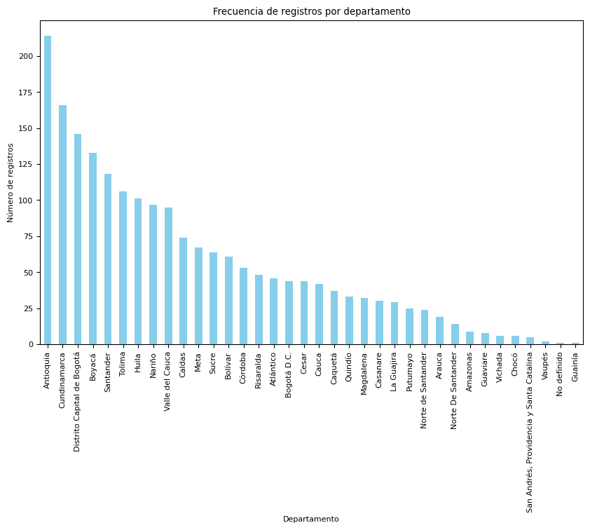

```python
department_counts = secop['departamento_paa'].value_counts()

plt.figure(figsize=(10, 6))
plt.rc('font', size=8)
department_counts.plot(kind='bar', color='skyblue')
plt.title('Frecuencia de registros por departamento')
plt.xlabel('Departamento')
plt.ylabel('Número de registros')
plt.show()
```

#### Gráfica de pastel: Top 10 departamentos con mayor número de registros

```python
(department_counts.head(10).sum()/department_counts.sum())*100
```

```
62.5
```

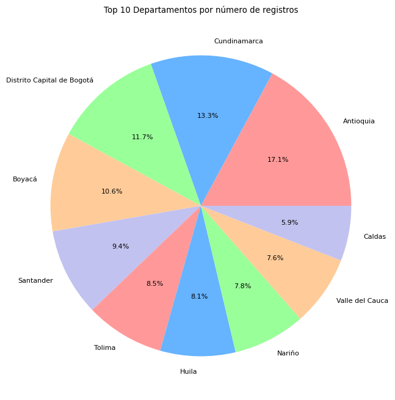

```python
top_5_departments = department_counts.head(10)
plt.figure(figsize=(8, 8))
top_5_departments.plot(kind='pie', autopct='%1.1f%%', colors=['#ff9999','#66b3ff','#99ff99','#ffcc99','#c2c2f0'])
plt.title('Top 10 Departamentos por número de registros')
plt.ylabel('')
plt.show()
```

#### Gráfica de barras: Municipios con más empresas (frecuencia de registros)

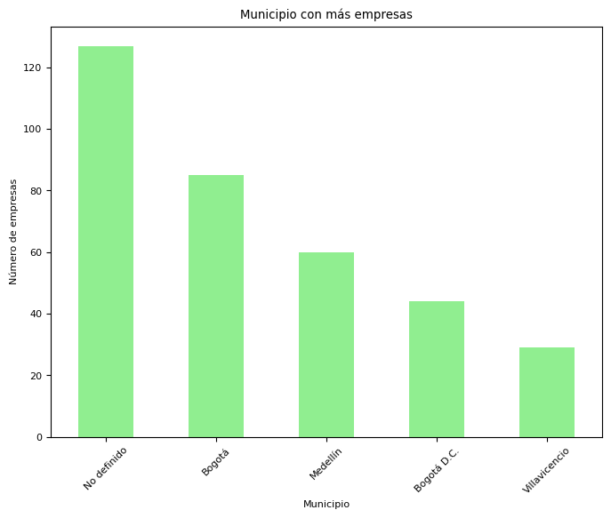

```python
municipality_counts = secop['municipio_paa'].value_counts()
top_municipality = municipality_counts.head(5)

plt.figure(figsize=(8, 6))
top_municipality.plot(kind='bar', color='lightgreen')
plt.title('Municipio con más empresas')
plt.xlabel('Municipio')
plt.ylabel('Número de empresas')
plt.xticks(rotation=45)
plt.show()
```

#### Gráfica de barras: Año con más empresas

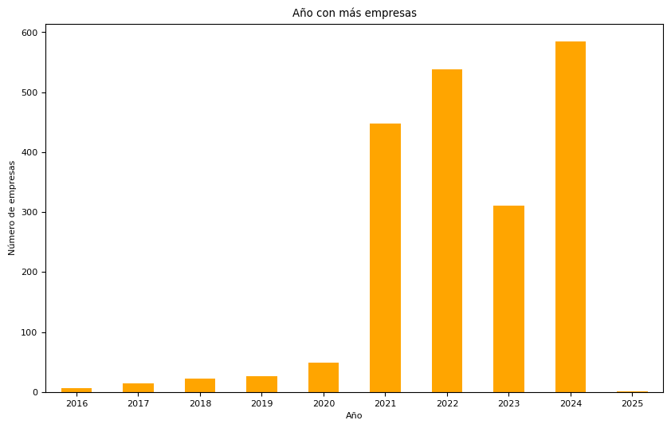

```python
# Gráfica de barras: Año con más empresas
year_counts = secop['anno'].value_counts()
year_counts = year_counts.sort_index()
plt.figure(figsize=(10, 6))
year_counts.plot(kind='bar', color='orange')
plt.title('Año con más empresas')
plt.xlabel('Año')
plt.ylabel('Número de empresas')
plt.xticks(rotation=0)
plt.show()
```

#### Grafica de Barras: Top 5 Entidades con mayor Presupuesto general

```python
!pip install numerize
```

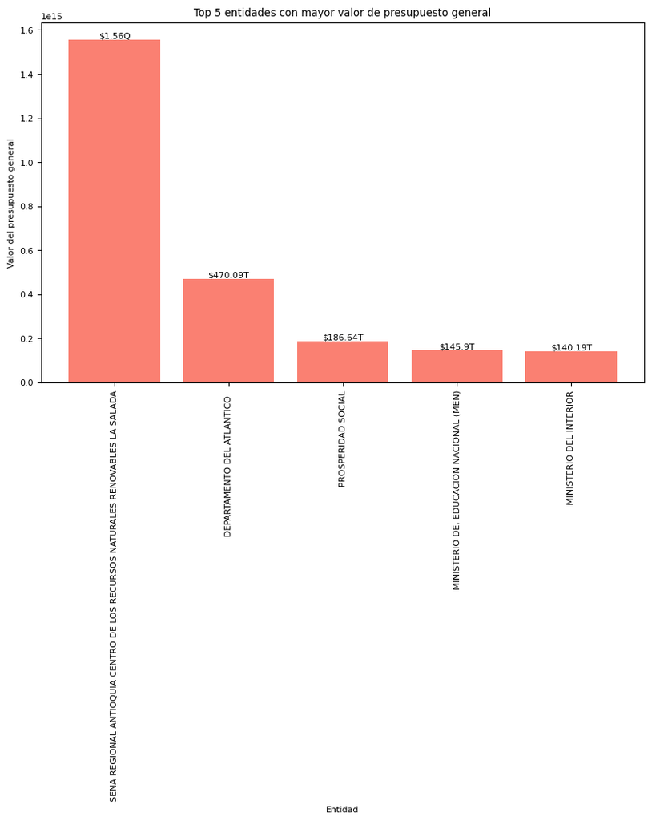

```python
from numerize import numerize
top_5_entidades = secop.sort_values(by='valor_presupuesto_general',ascending=False).head(5)
top_5_entidades['presupuesto_num'] = top_5_entidades['valor_presupuesto_general'].apply(lambda x: numerize.numerize(x))
plt.figure(figsize=(10, 6))
bars=plt.bar(top_5_entidades['nombre_entidad'], top_5_entidades['valor_presupuesto_general'], color='salmon')
plt.title('Top 5 entidades con mayor valor de presupuesto general')
plt.xlabel('Entidad')
plt.ylabel('Valor del presupuesto general')
plt.xticks(rotation=90)

num= top_5_entidades['valor_presupuesto_general'].values[0]
top_5_entidades['presupuesto_num'].values[0]=f"{num / 1e15:,.2f}Q"

# Agregar los valores numéricos en la parte superior de cada barra
for i, bar in enumerate(bars):
    yval = bar.get_height()
    plt.text(bar.get_x() + bar.get_width()/2, yval, '$'+top_5_entidades['presupuesto_num'].values[i], ha='center', va='bottom')


# Mostrar la gráfica
plt.show()
```

#### Gráfico de líneas: Tendencia del número de empresas a lo largo del tiempo

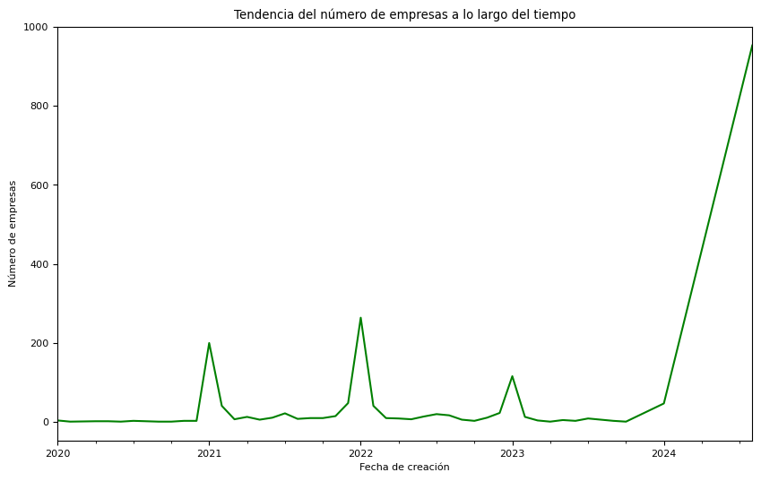

```python
# Agrupar por fecha de creación y contar el número de empresas
secop['fecha_de_creacion'] = pd.to_datetime(secop['fecha_de_creacion'])
trend = secop.groupby(secop['fecha_de_creacion'].dt.to_period('M')).size()

# Gráfico de líneas
plt.figure(figsize=(10, 6))
trend.plot(kind='line', color='green')
plt.title('Tendencia del número de empresas a lo largo del tiempo')
plt.xlabel('Fecha de creación')
plt.ylabel('Número de empresas')
plt.show()
```

#### Conclusiones

El año con más empresas muestra fluctuaciones en la creación empresarial, posiblemente influenciadas por factores económicos o políticas públicas. Además, las entidades con mayor presupuesto están centralizadas, lo que indica una concentración de recursos en áreas específicas.

Finalmente, la tendencia temporal en la creación de empresas refleja el entorno económico, mostrando si es favorable o desafiante para el crecimiento empresarial. Estos hallazgos sugieren la necesidad de políticas que promuevan un desarrollo más equitativo en regiones menos representadas.